# DP_22134458

```python
import cv2 as cv
```

```python
import cv2 as cv

# In VSC, right click on the 'clouds.jpg' and then 'Copy Path'


cv.imshow('image',img)
cv.waitKey(10000)
```

```python
# TO BE COMPLETED ...

# Example from Jungwoo Ryoo (2015)
import cv2
import numpy as np
# The 'types' module is needed to support dynamic creation of new types. In this case we dynamically create a new method type
import types #Import the types module

# Although 'concrete' this performs the role of the Strategy interface in the GoF example
class Strategy:
    """The Strategy Pattern class"""

    def __init__(self, function=None):
        self.name = "Default Strategy"
        self.image = 'C:/Users/Ypera/Documents/GitHub/Design-Patterns-stuff/clouds.jpg'
        #If a reference to a function is provided, replace the execute() method with the given function
        if function:
            self.execute = types.MethodType(function, self)

    # Although 'concrete' this performs an equivalent role to the GoF "AlgorithmInterface()"
    def execute(self): #This gets replaced by another version if another strategy is provided.
        img_rgb = cv2.imread(self.image)
        cv2.imshow('image', img_rgb)
        cv2.waitKey(0)
        cv2.destroyAllWindows()

# Replacement method 1 - this is a concrete implementation of 'AlgorithmInterface'
def strategy_one(self):
    img_rgb = cv2.imread(self.image)
    img_gray = cv2.cvtColor(img_rgb, cv2.COLOR_RGB2GRAY)
    cv2.imshow('Greyscale Image', img_gray)
    cv2.waitKey(0)
    cv2.destroyAllWindows()

# Replacement method 2 - this is a concrete implementation of 'AlgorithmInterface'
def strategy_two(self):
    print("{} is used to execute method 2".format(self.name))
    img_rgb = cv2.imread(self.image)
    img_blur = cv2.medianBlur(img_rgb, 7)
    cv2.imshow('Blurred image', img_blur)
    cv2.waitKey(0)
    cv2.destroyAllWindows()

def strategy_three(self):
    print("{} is used to execute method 3".format(self.name))
    img_rgb = cv2.imread(self.image)
    for x in np.nditer(img_rgb, op_flags=['readwrite']):
        x[...] = (255 - x)
    cv2.imshow('Colour negative', img_rgb)
    cv2.waitKey(0)
    cv2.destroyAllWindows()
def strategy_four(self):
    img_rgb = cv2.imread(self.image)
    img_grey = cv2.cvtColor(img_rgb, cv2.COLOR_RGB2GRAY)
    for x in np.nditer(img_grey, op_flags=['readwrite']):
        x[...] = (255 - x)
    cv2.imshow('Monochrome negative', img_grey)
def strategy_five(self):
    #Use bilateral filter for edge smoothing.
    num_down = 2 # number of downsampling steps
    num_bilateral = 7 # number of bilateral filtering steps
    img_rgb = cv2.imread(self.image)
    # downsample image using Gaussian pyramid
    img_color = img_rgb
    for _ in range(num_down):
        img_color = cv2.pyrDown(img_color)
    # repeatedly apply small bilateral filter instead of applying one large filter
    for _ in range(num_bilateral):
        img_color = cv2.bilateralFilter(img_color, d=9, sigmaColor=9, sigmaSpace=7)
    # upsample image to original size
    for _ in range(num_down):
        img_color = cv2.pyrUp(img_color)
    #Use median filter to reduce noise convert to grayscale and apply median blur
    img_gray = cv2.cvtColor(img_rgb, cv2.COLOR_RGB2GRAY)
    img_blur = cv2.medianBlur(img_gray, 7)
    #Use adaptive thresholding to create an edge mask detect and enhance edges
    img_edge = cv2.adaptiveThreshold(img_blur, 255, cv2.ADAPTIVE_THRESH_MEAN_C, cv2.THRESH_BINARY, blockSize=9, C=2)
    # Combine color image with edge mask & display picture, convert back to color, bit-AND with color image
    img_edge = cv2.cvtColor(img_edge, cv2.COLOR_GRAY2RGB)
    img_cartoon = cv2.bitwise_and(img_color, img_edge)
    # display
    cv2.imshow("Cartoon-ised image", img_cartoon);
    cv2.waitKey(0);
    cv2.destroyAllWindows()

# Let's create our default strategy
s0 = Strategy()
# Let's execute our default strategy
s0.execute()

# Let's create the first variation of our default strategy by providing a new behavior
s1 = Strategy(strategy_one)
# Let's set its name
s1.name = "Strategy One"
# Let's execute the strategy
s1.execute()

s2 = Strategy(strategy_two)
# Let's set its name
s2.name = "Strategy two"
# Let's execute the strategy
s2.execute()

s3 = Strategy(strategy_three)
# Let's set its name
s3.name = "Strategy three"
# Let's execute the strategy
s3.execute()

s4 = Strategy(strategy_four)
# Let's set its name
s4.name = "Strategy four"
# Let's execute the strategy
s4.execute()

s5 = Strategy(strategy_five)
# Let's set its name
s5.name = "Strategy five"
# Let's execute the strategy
s5.execute()
```

```
Strategy two is used to execute method 2
Strategy three is used to execute method 3
```

[output not shown]

## Logbook Exercise 11

```
mylist = ['item1', 'item2', 'item3']

iter_mylist = iter(mylist)

try:
    print( next(iter_mylist))
    print( next(iter_mylist))
    print( next(iter_mylist))
    # Exceeds numbe of items so should raise StopIteration exception
    print( next(iter_mylist))
except Exception as e:
    print(e)
    print(sys.exc_info())
```

```python
top10books = ['Book1', 'Book2', 'Book3', 'Book4', 'Book5', 'Book6', 'Book7', 'Book8', 'Book9', 'Book10']
mylist = top10books[:4]
iter_mylist = iter(mylist)
print(next(iter_mylist))
print(next(iter_mylist))
print(next(iter_mylist))
print(next(iter_mylist))
```

```
Book1
Book2
Book3
Book4
```

## Logbook Exercise 12 - The Adapter DP

- Modify Jungwoo Ryoo's Adapter Pattern example (the one with 'country' classes that 'speak' greetings) to showcase:
- the ***polymorphic*** capability of the Adpater DP
- the geo-data capabilities of ***matplotlib geographical projections*** ...
- in combination with ***Cartopy geospatial data processing*** package to ***produce maps and other geospatial data analyses***.
- A frequent problem in handling geospatial data is that the user often needs to convert it from one form of map projection (essentially a formula to convert the globe into a plane for map-representation) to another map projection
- Fortunately other clever people have written the algorithms we need
- Less fortunately, the interfaces of all the classes that return projections are different

## Development Stages

- We need ...
- first, to install the Python cartographic ***Cartopy*** package. In Anaconda launch a CMD.exe terminal and enter the following ...

```
    conda install -c conda-forge cartopy
```

- to insert a code cell below this one ... and copy the extended example of Ryoo's Adapter above (with 'speak' methods in Korean, British and German) in this ...
- an ***Adapter*** - Ryoo's adapter is already a well-engineered solution that requires no modification
- then to import some essential packages

```
    import cartopy.crs as ccrs
    import matplotlib.pyplot as plt
```

- then add the 'adaptee' classes - here represented by the plot axes and their map projections

```
   class PlateCarree:
       def __init__(self):
           self.name = "PlateCarree"
       def project_PlateCarree(self):
           ax = plt.axes(projection=ccrs.PlateCarree())
           return ax

   class InterruptedGoodeHomolosine:
       def __init__(self):
           self.name = "InterruptedGoodeHomolosine"
       def project_InterruptedGoodeHomolosine(self):
           ax = plt.axes(projection=ccrs.InterruptedGoodeHomolosine())
           return ax

   class AlbersEqualArea:
       def __init__(self):
           self.name = "AlbersEqualArea"
       def project_AlbersEqualArea(self):
           ax = plt.axes(projection=ccrs.AlbersEqualArea())
           return ax

   class Mollweide:
       def __init__(self):
           self.name = "Mollweide"
       def project_Mollweide(self):
           ax = plt.axes(projection=ccrs.Mollweide())
           return ax
```

- similarly to Ryoo's example you will need a collection to store projection objects
- again, simlarly to Ryoo, to create all the projection objects (e.g. `plateCarree =PlateCarree()` )
- again, similarly to Ryoo, to append to the collection key-value pairs for each projection and its projection method
- finally to traverse the list of objects to:

```
   # Create an axes with the specified projection
   ax = obj.project()
   # Attach Cartopy's default geospatially registered map/image of the world
   ax.stock_img()
   # Add the coastlines - highlight these with a black vector
   ax.coastlines()
   # Print the name of the object/projection
   print(obj.name)
   # Plot the axes, projection and render the map-image to the projection
   plt.show()
```

- The output should look something like this ...

```
PlateCarree
```

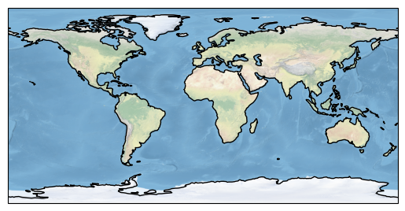

```
'not sure what to do on this one'
```

```python
import cartopy.crs as ccrs
import matplotlib.pyplot as plt
import numpy as np


class PlateCarree:
       def __init__(self):
              self.name = "PlateCarree"
       def project_PlateCarree(self):
              ax = plt.axes(projection=ccrs.PlateCarree())
              return ax

class InterruptedGoodeHomolosine:
       def __init__(self):
              self.name = "InterruptedGoodeHomolosine"
       def project_InterruptedGoodeHomolosine(self):
              ax = plt.axes(projection=ccrs.InterruptedGoodeHomolosine())
              return ax

class AlbersEqualArea:
       def __init__(self):
              self.name = "AlbersEqualArea"
       def project_AlbersEqualArea(self):
              ax = plt.axes(projection=ccrs.AlbersEqualArea())
              return ax

class Mollweide:
       def __init__(self):
              self.name = "Mollweide"
       def project_Mollweide(self):
              ax = plt.axes(projection=ccrs.Mollweide())
              return ax

obj = PlateCarree()

# Create an axes with the specified projection
ax = obj.project_PlateCarree()
# Attach Cartopy's default geospatially registered map/image of the world
ax.stock_img()
# Add the coastlines - highlight these with a black vector
ax.coastlines()
# Print the name of the object/projection
print(obj.name)
# Plot the axes, projection and render the map-image to the projection
plt.show()

"""not sure what to do on this one"""
```

## Logbook Exercise 13 - The Decorator DP

- Repair the code below so that the decorator reveals the name and docstring of aTestMethod()
- Note ... the @wrap decorator is NOT needed here

```
    <<< Name of the 'decorated' function ...  aTestMethod  >>>
    <<< Docstring for the 'decorated' function is ...  This is a method to test the docStringDecorator  >>>
    What is your name? ... Buggy Code
    Hello ... Buggy Code
```

```python
# REPAIR THE DECORATOR DP BELOW ...

def docStringDecorator(f):
    '''Decorator that automatically reports name and docstring for a decorated function'''
    print("<<< Name of the 'decorated' function ... ",self.__name__," >>> ")
    print("<<< Docstring for the 'decorated' function is ... ",self.__doc__," >>>")


def aTestMethod():
    '''This is a method to test the docStringDecorator'''
    nm = input("What is your name? ... ")
    msg = "Hello ... " + nm
    return msg

print(aTestMethod())
```

```
Hello ... c
```

## Logbook Exercise 14 - The 'conventional' Singleton DP

- Insert a code cell below here
- Copy the code from Dusty Philips' singleton
- Create two objects
- Test output using `print( ... )` and `repr( ... )` as well as the `==` operator to determine whether or not the two objects are the same and occupy the same memory addresses
- Make a note below of your findings

### My observations having tested the two objects are that they are the same, and occupy the same memory addresses, at least using the == operator

```python
## SINGLETON - Extended from Dusty Philips (2015) ##

class OneOnly:
    _singleton =  None
    def __new__(cls, *args, **kwargs):
        if not cls._singleton:
            cls._singleton = super(OneOnly, cls).__new__(cls, *args, **kwargs)
        return cls._singleton

p1 = OneOnly()
p2 = OneOnly()
print(p1)
print(p2)
repr(p1)
repr(p2)
if(p1 == p2):
    print("The objects are the same")
else:
    print("The objects are different")
if(repr(p1) == repr(p2)):
    print("The objects are the same")
else:
    print("The objects are different")
## CODE TO BE IMPLEMENTED FOR LOGBOOK EX 14 BELOW HERE ##
```

```
<__main__.OneOnly object at 0x000001EFD8BD1A90>
<__main__.OneOnly object at 0x000001EFD8BD1A90>
The objects are the same
The objects are the same
```

## Logbook Exercise 15 - The 'Borg' Singleton DP

- Repeat the exercise above ...
- Insert a code cell below here
- Copy the code from Alex Martelli's 'Borg' singleton
- Create THREE objects ... ***NOTE***: pass a name for the object when you call the constructor
- Test output using `print( ... )` and `repr( ... )` as well as the `==` operator to determine whether or not the objects are the same and occupy the same memory addresses
- ***Also*** can you use `print( ... )` to test the assertion in the notes above that ... "- `_shared_state` is effectively static and is only created once, when the first singleton is instantiated "
- Make a note below of your findings

```python
# Singleton/BorgSingleton.py
# Alex Martelli's 'Borg'

class Borg:
    _shared_state = {}

    def __init__(self):
        self.__dict__ = self._shared_state
        print("Value of self._shared_state is ..."+str(self._shared_state))

class Singleton(Borg):
    def __init__(self, arg):
        # Here the 'static' Borg class is updated with the state of the new singleton object
        Borg.__init__(self)
        self.val = arg
    def __str__(self):
        return self.val

## CODE TO BE IMPLEMENTED FOR LOGBOOK EX 15 BELOW HERE ##

s1 = Singleton("s1")
print(s1._shared_state)
s2 = Singleton("s2")
print(s2._shared_state)
s3 = Singleton("s3")
print(s3._shared_state)


if(s1 == s1):
    print("S1 is == to s1")
else:
    print("S1 is NOT == to s1")

if(s1 == s2):
    print("S1 is == to s2")
else:
    print("S1 is NOT == to s2")

if(s1 == s3):
    print("S1 is == to s3")
else:
    print("S1 is NOT == to s3")

if(s2 == s3):
    print("S2 is == to s3")
else:
    print("S2 is NOT == to s3")
```

```
Value of self._shared_state is ...{}
{'val': 's1'}
Value of self._shared_state is ...{'val': 's1'}
{'val': 's2'}
Value of self._shared_state is ...{'val': 's2'}
{'val': 's3'}
S1 is == to s1
S1 is NOT == to s2
S1 is NOT == to s3
S2 is NOT == to s3
```

## Logbook Exercises 16 and 17

- Per the assignment brief, for the third and final part of your assignment (copied below), note that it is necessary to write about TWO additional Design Patterns ...
  - *In you logbooks draw on a selection of Two Design Patterns, and document these using the following headings: 1 intent; 2 motivation; 3 structure (embed UML diagrams if applicable); 4 implementation; 5 sample code (your working example); 6 evaluation – raise any key points concerning programming language idioms, consequences of using the pattern, examples of appropriate uses with respect to application, architecture and implementation requirements* [40 marks]
- Clearly it will be necessary to insert both markdown and code cells.
- Please make sure that all cells are properly titled with the excercise they represent
- Use and embed any screen capture that supports your assignment responses
- Suitable task subjects include:
- Demonstrating a new pattern (one which we haven't encountered)
- Presenting a pattern that we have addressed in a new/alternative/re-engineered format
- Converting a pattern to another programming language
- Identifying patterns in well known frameworks (e.g. for Python web development you might examine Django, Flask and/or Jinja2)

Design Pattern 1: Observer

Intent: This design pattern works on defining a depenency between objects so when one changes in some way the others (observers) change also automatically

Motivation: Often multiple components will need to react to changes in event architecture, using the observer pattern one can design a system where these changes can occur dynamically without explicitly defined dependencies

```python
class StockMarket:
    def __init__(self):
        self._observers = []
        self._price = 0

    def attach(self, observer):
        self._observers.append(observer)

    def detach(self, observer):
        self._observers.remove(observer)

    def notify(self):
        for observer in self._observers:
            observer.update(self._price)

    def set_price(self, price):
        self._price = price
        self.notify()

class Observer:
    def update(self, price):
        pass

class MobileApp(Observer):
    def update(self, price):
        print(f"Mobile App: Stock price updated to ${price}")

class Website(Observer):
    def update(self, price):
        print(f"Website: Stock price updated to ${price}")

market = StockMarket()
app = MobileApp()
web = Website()

market.attach(app)
market.attach(web)

market.set_price(100)
market.set_price(105)
```

```
Mobile App: Stock price updated to $100
Website: Stock price updated to $100
Mobile App: Stock price updated to $105
Website: Stock price updated to $105
```

```python
Evaluation
Automatically alters displayed variables when relevent, making the system more modular
```